# Coursework Report

*N* removed NAs: 3

*N* removed typo: 1

*N* removed <18: 24

*N* total clean: 123

| Group | *N* | *M*<sub>age</sub> | *M*<sub>rating</sub> |
| --- | --- | --- | --- |
| Control | 62 | 21.34 | 5.30 |
| Experim | 61 | 21.03 | 6.35 |

**Main analysis results**

*t*(121) = -6.7, *p* < .001

[interactive chart not shown]

[figure not shown]

[interactive chart not shown]

# Coursework Report

Analysing Data, Spring 2020

# Methods

## Participants

*Table 1* Summary of Participant Demographics by Experimental Condition

| Condition | Count | *M*<sub>age</sub> | *SD*<sub>age</sub> |
| --- | --- | --- | --- |
| White | 62 | 21.34 | 2.28 |
| Red | 61 | 21.03 | 2.02 |

## Design

The study examined the replicability of the red effect and questions whether it really exists. The research question was to discover if red enhances women’s attraction to men. The conceptual hypothesis was that women’s ratings of perceived attractiveness of a man are higher when in conjunction with the colour red. Participants were randomly allocated to either experimental condition. The manipulated independent variable was whether participants viewed a black and white photograph on a red or a white background. The dependent variable was participants’ rating of perceived attractiveness of the man in the photograph. This was measured on three 9-point scales representing “not at all attractive” at 1 ranging to “extremely attractive” at 9. Item_1, Item_2 and Item_3 represent the face-valid questions of perceived attractiveness: “How attractive do you think this person is?”, “How pleasant is this person to look at?”, and “If I were to meet the person in this picture face to face, I would think he is attractive.”, respectively. From these three scores a composite score was created of the mean attractiveness rating each participant gave from the three measures. The operational hypothesis was that a photograph on a red background will receive a higher perceived attractiveness composite rating from participants on a 1-9 scale than the same photograph viewed on a white background. This hypothesis will be statistically analysed using a t-test.

# Results

The participants ratings of perceived attractiveness of the photograph were analysed by their colour conditions. Table 2 shows the mean scores for each rating of attractiveness across the two colour conditions.

*Table 2* Summary of Mean Ratings by Colour Condition

| Condition | Rating 1 Mean | Rating 1 SD | Rating 2 Mean | Rating 2 SD | Rating 3 Mean | Rating 3 SD |
| --- | --- | --- | --- | --- | --- | --- |
| White | 5.21 | 1.32 | 5.37 | 1.62 | 5.32 | 1.49 |
| Red | 6.18 | 1.51 | 6.41 | 1.38 | 6.46 | 1.48 |

The means across the three rating scales were averaged to form a composite score of attractiveness rating for each colour condition. Participants in the control group had an average total score of 5.3/9. Participants in the experimental group had an average total score of 6.35/9.

The photograph on the red background was given higher mean ratings of attractiveness (6.35), than the photograph on the white background (5.3). The following graph compares the composite attractiveness rating of the photograph from the red and white colour conditions.

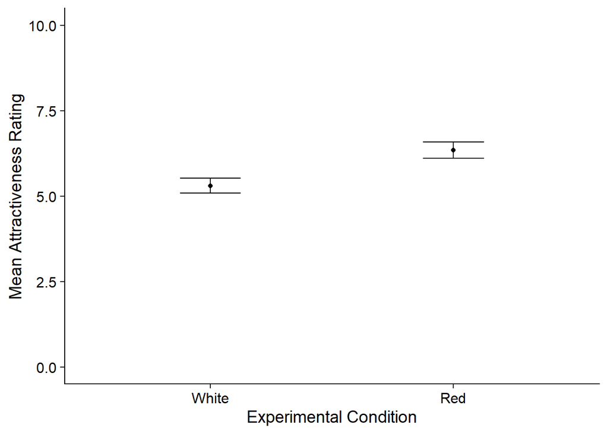

Fig.1 Percieved Attractiveness Rating by Experimental Colour Condition

An independent-samples t test was conducted to investigate the effect that the red colour condition had on perceived attractiveness. The analysis compares the difference in means to the standard deviation of the differences in means. The probability value p < 0.05 thus the difference in means was significant (*M*<sub>diff</sub> = 1.05, 95% CI [-0.74, -1.36], *t* (121) = -6.7, *p* = 0). The analysis indicated that participants in the experimental condition perceived the man in the photograph as more attractive than those in the control condition.

The null hypothesis of the t-test is that the two sample means come from the same population, suggesting that attractiveness ratings should be the same and not affected by the colour conditions. The probability is very small (*p* = 0) thus this result is not likely to be due to chance, suggesting that the null hypothesis can be rejected in favour of the experimental hypothesis.

It can be concluded that there is a relationship between colour condition and perceived attractiveness in this experiment. The result of the analysis suggests that whether a participant viewed a photograph on a red or white background influenced their subsequent percieved attractiveness rating of the subject of the photograph.

# Discussion

The experiment used composite ratings from two independent conditions to compare the difference in attraction when a photograph is presented in conjunction with the colour red and with an achromatic background. The hypothesis that a photograph on a red background will receive a higher perceived attractiveness composite rating from participants on a 1-9 scale than the same photograph viewed on a white background was supported by the data. Participants in the red colour condition gave higher mean ratings of attractiveness to the photograph across all three questions than participants in the white control condition. Statistical analysis using a t-test supported that the findings were significant and that there is a relationship between the colour of the background that a photograph is presented with and subsequent ratings of attractiveness. This supports the red effect hypothesized and highlighted in the literature.

The Elliot et al (2010) study found evidence that pairing with a red background, as replicated in this study, or wearing red clothing significantly increased the attractiveness ratings given by female participants. The pattern of results from this study are very similar to those found in the original, suggesting that the experiment was a good replication. Perceived attractiveness increased in the red condition compared to the white condition. This replicability further supports the red effect and its reliability. Furthermore, the current study used a larger sample of participants, thus the difference in means was more significant than found in the previous research suggesting the identified relationship has greater validity than could be attributed previously.

Numerous replication attempts have been made of the Elliot et al (2010) study. Some researchers failed to find a correlation or a significant impact of red with attractiveness (Perperkoorn, Roberts, & Pollet, 2016; Hesslinger, Goldbach, & Carbon, 2015). This may suggest that there is no real impact of conjunction with the colour red in perceived attractiveness. Francis (2013) suggested that the results of the original study were contaminated with publication bias. Despite this claim, the results have been well replicated in both this study and repeatedly in other research by independent laboratories which supports the evidence for the red-attractiveness effect in women viewing men (Elliot & Maier, 2013).

Due to the simplistic, one-variable design, the current study can identify relationships between red and attraction but is unable to establish any factors which may mediate this phenomenon. Elliot et al (2012) hypothesised that participant’s perception of status influences the red effect and suggest an evolutionary link between societal ranking and sexual selection. There is also support among the literature that enhanced facial redness increases perceptions of health as well as attractiveness implying that health may act as a factor to mediate the red-attractiveness relationship (Re et al, 2011). Roberts, Owen and Havlicek (2010) identified that wearing red clothing had subtle influences on men’s expressions and posture which increased their ratings of attraction from women.

In addition to mediating factors of the red effect, We et al (2014) proposed that sexual dimorphism acted as a moderating factor in whether conjunction with red increases sexual attraction. The current study was unable to identify, support or dispute the involvement of any such factors and their impact on the red effect. Ideally, future research questions can be based around identifying and exploring these moderating factors to explain any relationships between association with the colour red, psychological influences, and perceived physical health, status in society and attraction.

Research by Roberts, Owen and Havlicek (2010) found further support for the existence of the red effect, perhaps on a more universal scale, with evidence that clothing colour affected ratings of attraction in judgements of both males and females. Interestingly, they also found that conjunction with the colour black increased sexual attractiveness ratings with effects equivalent to those associated with red. Subsequent research could explore whether the colour-association effect is universal, exists with certain colours or is unique to red.

This data from this experiment replication does indeed identify a relationship between the presence of red and increased perceived attraction. As thus it lends strong support to the existence of the hypothesized red effect. However, it is apparent that the findings of the current study give an incomplete perspective of the colour-attraction association, much like all the previous research. It may be that the actual red effect, if real, is not as holistic, encompassing and universal of a phenomenon than was first imagined. It is more likely that the red effect exists as part of an intricately related group of many factors that influence one another to mediate and moderate attraction. The red effect may be restricted to certain scenarios and reliant upon individual differences which would explain its dynamic allusivity to identify and inconsistency within the many replications. The way in which people experience attraction, like all human processes is extremely complex and the evidence suggests that the red effect acts, at least, as a small but significant factor in this.

# References

Elliot, A. J., Niesta Kayser, D., Greitemeyer, T., Lichtenfeld, S., Gramzow, R. H., Maier, M. A., & Liu, H. (2010). Red, rank, and romance in women viewing men. Journal of Experimental Psychology: General, 139(3), 399–417.

Elliot, A. J., & Maier, M. A. (2013). The Red-Attractiveness Effect, applying the Ioannidis and Trikalinos (2007b) test, and the broader scientific context: A reply to Francis. Journal of Experimental Psychology: General, 142(1), 297-300.

Francis, G. (2013). Publication bias in “Red, rank, and romance in women viewing men,” by Elliot et al. Journal of Experimental Psychology: General, 142(1), 292-296.

Hesslinger, V. M., Goldbach, L., & Carbon, C.-C. (2015). Men in red: A reexamination of the red-attractiveness effect. Psychonomic Bulletin & Review, 22(4), 1142–1148.

Peperkoorn, L. S., Roberts, S. C., & Pollet, T. V. (2016). Revisiting the Red Effect on Attractiveness and Sexual Receptivity: No Effect of the Colour Red on Human Mate Preferences, Evolutionary Psychology, 14(4), 1-13.

Re, D. E., Whitehead, R. D., Xiao, D., & Perrett, D. I. (2011). Oxygenated-Blood Colour Change Thresholds for Perceived Facial Redness, Health, and Attractiveness. PLoS ONE, 6(3).

Roberts, S. C., Owen, R. C., & Havlicek, J. H. (2010). Distinguishing between Perciever and Wearer Effects in Clothing Colour-Associated Attributions. Evolutionary Psychology, 8(3), 350-364.

Wen, F., Zuo, B., Wu, Y., Sun, S., & Liu, K. (2014). Red is Romantic, but Only for Feminine Females: Sexual Dimorphism Moderates Red Effect on Sexual Attraction. Evolutionary Psychology, 12(4), 719-735.